# Introduction to RLQ analysis

Frelat, R.

7th June 2021

This document provides an introduction to RLQ analysis. The tutorial targets students and scientists in marine biology and ecology with previous knowledge of the [R software](https://cran.r-project.org/).

# 1. Preliminaries

## 1.1. Load ade4 package

The analyses require the R packages [ade4 (v ≥ 1.7.16)](https://pbil.univ-lyon1.fr/ade4/home.php?lang=eng).

```r
library(ade4)
```

If you want to plot a map with country border, then you would also need the packages `maps (v ≥ 3.3)` and `mapdata (v ≥ 2.3)`.

```r
library(maps); library(mapdata)
```

If you get an error message, check that the R packages are installed correctly. If not, use the command: `install.packages(c("ade4", "maps", "mapdata"))`.

## 1.2 Load the example dataset

Make sure the file `NorthSea_FishTraitEnv.Rdata` is in your working directory, then load it in R.

```r
load("NorthSea_FishTraitEnv.Rdata")
```

The Rdata file contains four objects: - `abu` containing the abundance of taxa in grid cells - `env` containing the environmental condition per grid cell - `trait` containing the trait information per taxa - `coo`: the coordinates of each grid cell

```r
all(row.names(abu)==row.names(env))
```

```
## [1] TRUE
```

```r
all(colnames(abu)==row.names(trait))
```

```
## [1] TRUE
```

Using this fish community of the North Sea as an example, you will learn how to compute the RLQ analysis.

## 1.3 Quick summary of the variables

```r
dim(trait)
```

```
## [1] 90  7
```

```r
names(trait)
```

```
## [1] "Trophic level"  "K"              "Lmax"           "Lifespan"
## [5] "Offspring size" "Fecundity"      "Age maturity"
```

```r
dim(env)
```

```
## [1] 111   7
```

```r
names(env)
```

```
## [1] "Depth"   "SBT"     "SBS"     "Chl"     "SBT_sea" "Chl_sea" "Fishing"
```

# 2. Single multivariate analysis

## 2.1 COA on abundance matrix L (sites x species)

```r
dim(abu) # 111 sites x 90 species
```

```
## [1] 111  90
```

```r
coa.abu <- dudi.coa(abu, scannf = FALSE, nf=2)
```

## 2.2 PCA on traits matrix Q (species x traits)

Using species weight from previous COA

Mention that it could be mix dataset (Hill and Smith analysis)

```r
dim(trait) # 90 species x 7 continuous traits
```

```
## [1] 90  7
```

```r
pca.trait<-dudi.pca(trait, scannf = FALSE,
                     row.w = coa.abu$cw)
```

## 2.3 PCA on environment matrix R (sites x environment)

using sites weight from previous COA

Same here, it could be categorical variables And the number of environmental variables do not have to match the number of traits (indeed, easier if it doesn’t match)

```r
dim(env) # 111 sites x 7  environmental variables
```

```
## [1] 111   7
```

```r
pca.env <- dudi.pca(env, scannf = FALSE,
                     row.w = coa.abu$lw)
```

# 3. Run RLQ analysis and interpret the results

## 3.1 Compute RLQ analysis

```r
rlqF <- rlq(pca.env, coa.abu, pca.trait,
               scannf = FALSE)
```

## 3.2 Visualize the output

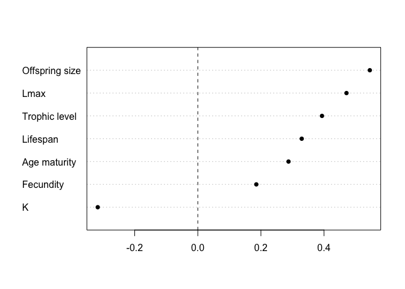

```r
#Plot traits score
t1 <- order(rlqF$c1[,1])
dotchart(rlqF$c1[t1,1], pch=16,
         labels = names(trait)[t1])
abline(v=0, lty=2)
```

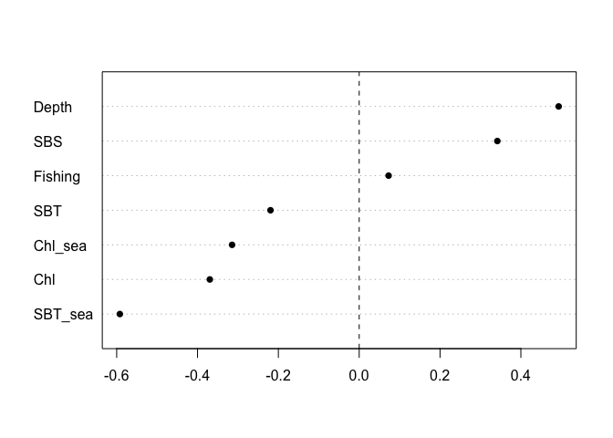

```r
#Plot environment score
e1 <- order(rlqF$l1[,1])
dotchart(rlqF$l1[e1,1], pch=16,
         labels = names(env)[e1])
abline(v=0, lty=2)
```

## 3.2 Visualize the output

```r
#Choice of diverging color scale (from RColorBrewer)
colpal <- terrain.colors(6)
#Choice of diverging color scale (from RColorBrewer)
# colpal <- rev(brewer.pal(6,"RdYlBu"))
#Set the color of each site based on RLQ score
colo <- colscale(rlqF$lR[,1], colpal)

#Plot the map
apply(coo, 2, range)
```

```
##      Longitude Latitude
## [1,]      -5.5     51.5
## [2,]      12.5     61.5
```

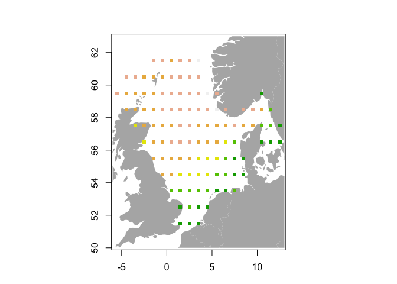

```r
map("world", xlim=c(-6, 13), ylim=c(50, 63),
    mar=c(5,5,1,0), col="gray70", fill=TRUE,
    border=NA, lforce="e")
points(coo, col=colo$col, pch=".", cex=6)
map.axes()
```

#4. Fourth corner analysis

Fourth corner analysis takes very long to compute. Additionally, multiple repetitions are needed in order to estimate the p-values with enough precision before p-values are adjusted for multiple testing.

*might not be usefull here…*

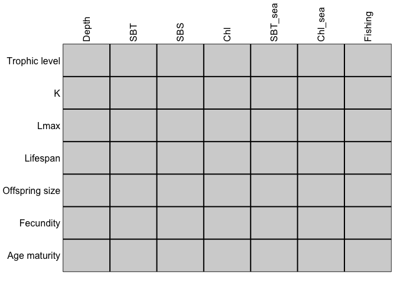

```r
nrep <- 1000
fc <- fourthcorner(env, abu, trait, nrepet=nrep)
plot(fc)
```

# References

Dray, S., Choler, P., Dolédec, S., Peres-Neto, P. R., Thuiller, W., Pavoine, S., & ter Braak, C. J. (2014). Combining the fourth‐corner and the RLQ methods for assessing trait responses to environmental variation. Ecology, 95(1), 14-21. [DOI 10.1890/13-0196.1](https://doi.org/10.1890/13-0196.1)